# Analyse mbPLs avec estimation du poids des blocs et des variables dans l’explication de Y et sélection de variables

true

2025-03-19

# Variables X pouvant expliquer le statut BESASP des élevages NE

```r
donnees <- readRDS("/home/rogerbernat/Documents/Projet_Stat_2025_modelisation/data_post_etape_4_Mean.Rdata")
```

————-Mise en forme des données

On commence par centrer-réduire toutes les variables quantitatives du jeu de données:

```r
set.seed(1234567)
data.clean <- donnees[-1]
rownames(data.clean) <- donnees$CODE_ELEVAGE
noms.ligne <- donnees$CODE_ELEVAGE
for(i in 1:length(data.clean)){
  if(is.numeric(data.clean[i]))
  data.clean[i] <- scale(data.clean[i])
}
```

N=100 p = 22 dont variable Y

Découpage en blocs:

```r
X01_Logement_Entretien <- data.clean[, c("X22x1_LOC_INF_rec", "X07x1_AN_CONST4_mean_3", "ENG_TROU", "T13_ENG_milieuDegrad.x")]
X02_Alimentation <- data.clean[, c("T10_PS_EauDebi_3", "T10_PS_AlimPoNourrLongpPo", "X09x3_FAB_CROISS_reg_rec")]
X03_Gestion_Maladies <- data.clean[, c("X18x2_ABBTX_PS", "X19x2_ABB_E")]
X04_Biosecurite <- data.clean[, c("X12x2_MAT_PC", "X12x2_MAT1FRLAV_1", "T16_BS_TenueSpeciElev", "X13x2_QUAI_t")]
X05_Facteurs_Infectieux <- data.clean[, c("A03_Pos10sVERS", "A03_PosSeroMyAs", "A03_TxPosSero22sTgReel", "A04_My10Mfloc", "A05_TxPos10sGRIPPEReel")]
X06_Caracteristiques_Generales <- data.clean[, c("X06x1_gene_majo_1_rec", "X25x1_ElvAlterChoiPers", "LR_LRF")]
```

Transformation des vbl quali en vbl indicatrices pour le modèle:

```r
data <- list(X01_Logement_Entretien, X02_Alimentation, X03_Gestion_Maladies, X04_Biosecurite, X05_Facteurs_Infectieux, X06_Caracteristiques_Generales)

for(i in 1:length(data)){
  df <- data[[i]]
  for(var in names(df)){
    if(is.factor(df[[var]])){
      df <- dummy_cols(df, var, remove_selected_columns = TRUE, remove_most_frequent_dummy = TRUE)
    }
  }
  data[[i]] <- df
}
```

```r
dummy_y <- data.frame(y = data.clean$y)

# Create des 3 Y
dummy_y$sain <- as.integer(dummy_y$y == "Sain")
dummy_y$ps_malade <- as.integer(dummy_y$y == "PS_malade")
dummy_y$eng_malade <- as.integer(dummy_y$y == "ENG_malade")
```

```r
#création d'un vecteur Y
bloc.Y <- dummy_y[,2:4]
data[[7]] <- bloc.Y
```

Renommer les blocs:

```r
new_names <- c("X01_Logement_Entretien", "X02_Alimentation", "X03_Gestion_Maladies", "X04_Biosecurite", "X05_Facteurs_Infectieux", "X06_Caracteristiques_Generales", "Bloc_Y")
names(data) <- new_names
```

| ———————–ANALYSE ——————————– |
| --- |

# PLS Multibloc

## Préparation des données

```r
Y <- data[[7]]
dudiY.NE <- dudi.pca(Y, center = TRUE, scale = TRUE, scannf = FALSE)
ktabX.NE <- ktab.list.df(data[1:6])
```

## mbPLS

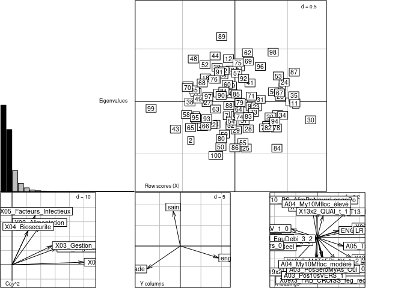

```r
res.mbpls2   <- mbpls(dudiY.NE, ktabX.NE, scale = TRUE, option = "uniform", scannf = F, nf = 10)
res.plot     <- plot(res.mbpls2)
```

```r
res.2foldcv2 <- testdim(res.mbpls2, nrepet = 500)  # calcul long
```

NB : les variables X sont centrées et réduites à ce niveau

## Choix des dimensions

Choix du nombre de dimensions a interpréter (minimiser l’erreur de prédiction 2-fold et d’explication)

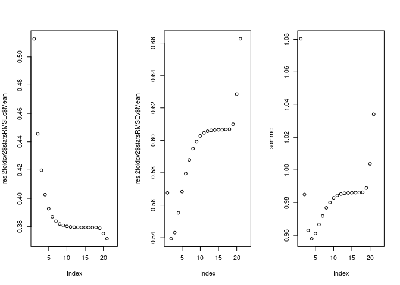

```r
par(mfrow = c(1, 3))
somme <- res.2foldcv2$statsRMSEv$Mean + res.2foldcv2$statsRMSEc$Mean
plot(res.2foldcv2$statsRMSEc$Mean)
plot(res.2foldcv2$statsRMSEv$Mean)
plot(somme)
```

```r
match(min(na.omit(somme)), somme)
```

```
## [1] 4
```

4 dimensions ## Analyse

```r
opt.dim <- 4
res.boot <- randboot(res.mbpls2, opt.dim, nrepet = 500) # calcul long
```

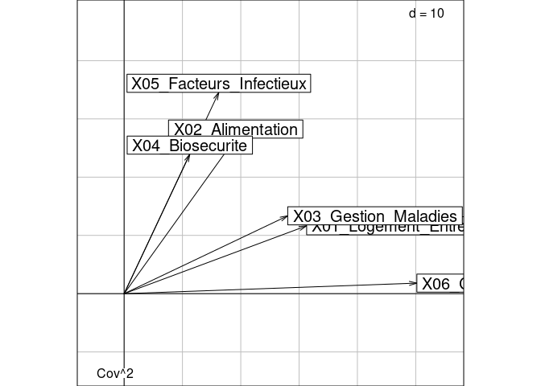

```r
res.plot[[3]]   # Blocs Xk
```

Le bloc 06 contribu uniquement à la construction du premier axe. Le reste des bocs contribuent tous à la costruction des deux axes. Cependant les blocs 5,2,4 (tangibles, plus directes) plus dans le deuxième axe et les blocs 3-1 (moins directes: logistique) dans le premer

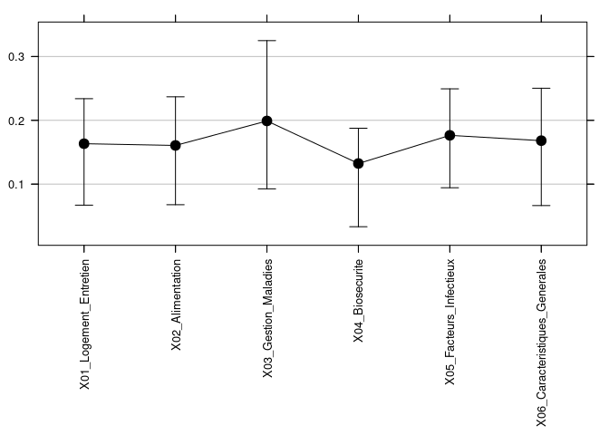

```r
plot(res.boot$bipc)                  # Importance des blocs explicatifs (seuil 1/K, K = nb blocs)
```

6 blocs X donc 1/k=17%; 0.17 Tous les blocs sont >0 et semblent >0.16 sauf X04 Biosecurite IC passe dans l’intervalle comprenant 0.16 et gestion des maladies semble avoir un poid plus important.

### Variables

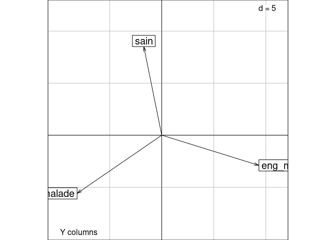

```r
res.plot[[4]]   # Variable Y
```

Sain positivement dans l’axe 2.

ps_malade dans les deux axes négativement, eng_malade, negativement axe 2 et positivement axe 1, eng et ps semblent s’opposer.

Interpret :

- Axe 2 discrimine malade sain
- Axe 1 discrimine eng ou ps malade

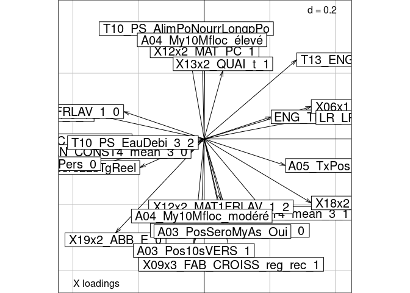

```r
res.plot[[5]]   # Variables Xk
```

TODO/ Utile ? Var les plus carac peut-être

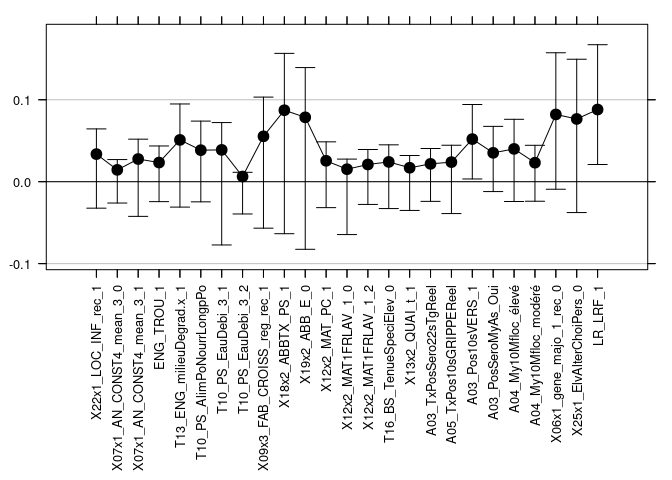

```r
plot(res.boot$vipc)                  # Importance des variables explicatives (pour tout le bloc Y ; seuil 1/P)
```

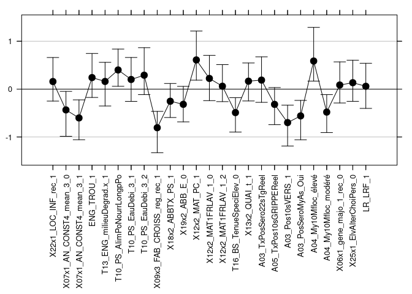

```r
plot(res.boot$XYcoef[[1]])           # Importance des variables explicatives (pour la variable y1 ; seuil 0)
```

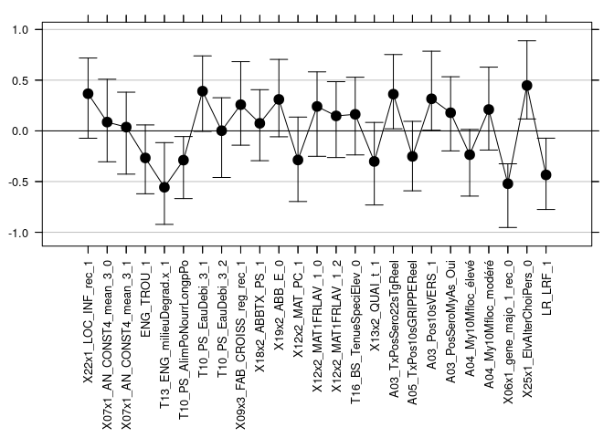

```r
plot(res.boot$XYcoef[[2]])           # Importance des variables explicatives (pour la variable y2 ; seuil 0)
```

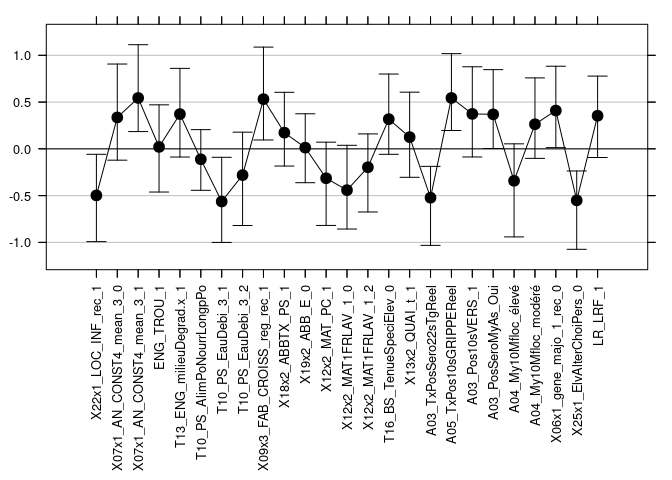

```r
plot(res.boot$XYcoef[[3]])           # Importance des variables explicatives (pour la variable y2 ; seuil 0)
```

On cherche à identifier les variables dont toutes les modalités ont un IC qui passe par zéro pour toutes les modalités de Y.

```r
# Init variable toujours dont IC passe par 0
tjrs_0 <- function(res.boot){
  toujours_0 <- rep(TRUE, nrow(res.boot$XYcoef[[1]]$stats))

  # Pour chaque modalité de Y
  for (i in 1:length(Y)) {
    # selection des bornes
    lower <- res.boot$XYcoef[[i]]$stats[, 1]
    upper <- res.boot$XYcoef[[i]]$stats[, 2]

    # Regarde si IC dans 0
    ci_includes_zero <- (lower <= 0) & (upper >= 0)

    # mise à jour de la variable tjrs_0
    toujours_0 <- toujours_0 & ci_includes_zero
  }
  return(toujours_0)
}
toujours_0 <- tjrs_0(res.boot)
toujours_0
```

```
##        X22x1_LOC_INF_rec_1   X07x1_AN_CONST4_mean_3_0
##                      FALSE                      FALSE
##   X07x1_AN_CONST4_mean_3_1                 ENG_TROU_1
##                      FALSE                       TRUE
##   T13_ENG_milieuDegrad.x_1  T10_PS_AlimPoNourrLongpPo
##                      FALSE                      FALSE
##         T10_PS_EauDebi_3_1         T10_PS_EauDebi_3_2
##                      FALSE                       TRUE
## X09x3_FAB_CROISS_reg_rec_1           X18x2_ABBTX_PS_1
##                      FALSE                       TRUE
##              X19x2_ABB_E_0             X12x2_MAT_PC_1
##                       TRUE                      FALSE
##        X12x2_MAT1FRLAV_1_0        X12x2_MAT1FRLAV_1_2
##                       TRUE                       TRUE
##    T16_BS_TenueSpeciElev_0             X13x2_QUAI_t_1
##                      FALSE                       TRUE
##     A03_TxPosSero22sTgReel     A05_TxPos10sGRIPPEReel
##                      FALSE                      FALSE
##           A03_Pos10sVERS_1        A03_PosSeroMyAs_Oui
##                      FALSE                      FALSE
##        A04_My10Mfloc_élevé       A04_My10Mfloc_modéré
##                      FALSE                      FALSE
##    X06x1_gene_majo_1_rec_0   X25x1_ElvAlterChoiPers_0
##                      FALSE                      FALSE
##                   LR_LRF_1
##                      FALSE
```

Ainsi on supprime :

- ENG_TROU
- X18x2_ABBTX_PS
- X19x2_ABB_E
- X12x2_MAT1FRLAV
- X13x2_QUAI_t

```r
var.suppr <- c("ENG_TROU", "X18x2_ABBTX_PS",
              "X19x2_ABB_E", "X12x2_MAT1FRLAV", "X13x2_QUAI_t")
var_dummy.suppr <- grep(paste(var.suppr, collapse = "|"), names(toujours_0), value = TRUE)
for(i in seq_along(data)) {
  data[[i]] <- data[[i]] %>%
    dplyr::select(-any_of(var_dummy.suppr))  # Explicit dplyr::select
}
# Détection si bloc vide et suppression
bloc.vide <- c()
for(i in 1:length(data)){
  if(ncol(data[[i]]) == 0){
    bloc.vide <- c(bloc.vide, i)
  }
}
bloc.vide # blocs a supprimer
```

```
## [1] 3
```

```r
data <- data[-bloc.vide]

# detection blocs a variables uniques
bloc.unic <- c()
for(i in 1:length(data)){
  if(ncol(data[[i]]) == 1){
    bloc.unic <- c(bloc.unic, i)
  }
}
bloc.unic
```

```r
names(data)
```

```
## [1] "X01_Logement_Entretien"         "X02_Alimentation"
## [3] "X04_Biosecurite"                "X05_Facteurs_Infectieux"
## [5] "X06_Caracteristiques_Generales" "Bloc_Y"
```

Le bloc de gestion des maladies n’et plus présent

## Deuxième mb-pls

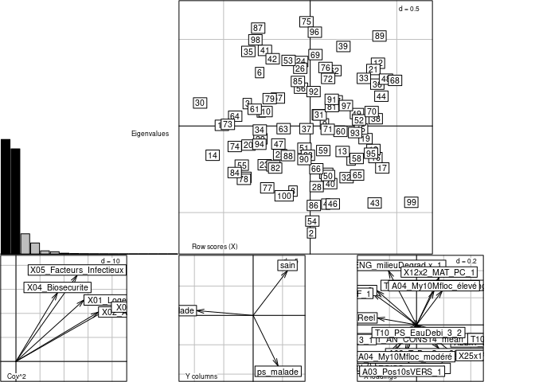

```r
dudiY.NE <- dudi.pca(Y, center = TRUE, scale = TRUE, scannf = FALSE)
ktabX.NE <- ktab.list.df(data[1:5])
res.mbpls2   <- mbpls(dudiY.NE, ktabX.NE, scale = TRUE, option = "uniform", scannf = F, nf = 10)
res.plot     <- plot(res.mbpls2)
```

```r
res.2foldcv2 <- testdim(res.mbpls2, nrepet = 500)  # calcul long
```

## Choix des dimensions

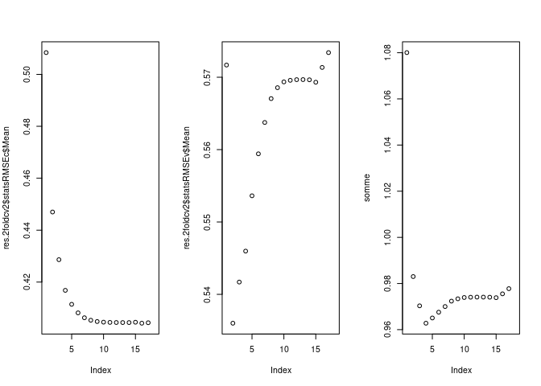

```r
par(mfrow = c(1, 3))
somme <- res.2foldcv2$statsRMSEv$Mean + res.2foldcv2$statsRMSEc$Mean
plot(res.2foldcv2$statsRMSEc$Mean)
plot(res.2foldcv2$statsRMSEv$Mean)
plot(somme)
```

```r
match(min(na.omit(somme)), somme)
```

```
## [1] 4
```

On prend 4 dimensions encore une fois.

## Analyse

```r
opt.dim <- 4
res.boot <- randboot(res.mbpls2, opt.dim, nrepet = 500) # calcul long
```

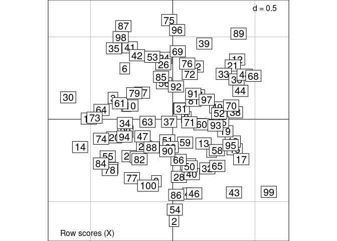

```r
res.plot[[1]]
```

## Blocs

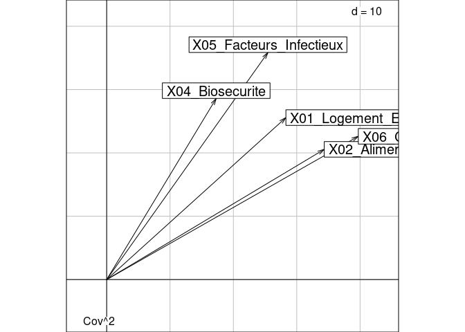

```r
res.plot[[3]]   # Blocs Xk
```

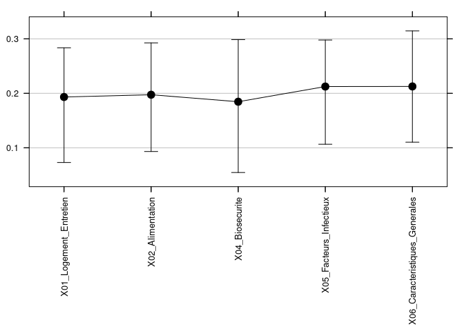

```r
plot(res.boot$bipc)                  # Importance des blocs explicatifs (seuil 1/K, K = nb blocs)
```

5 blocs X donc 1/k=20%; 0.2 Tous les blocs ont leur IC qui passe par 0.2 cependant, deux semblent être plus importants : Facteurs infectieux et caractéristiques géneŕales. Le moins : biosécurité.

## Variables

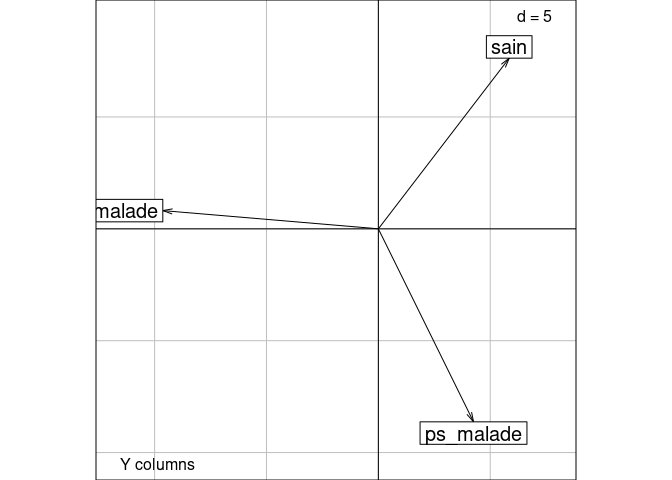

```r
res.plot[[4]]   # Variable Y
```

- axe 1 : discrimine selon eng_malade ou pas *axe 2 : sain ou ps_malade (sain positif, ps_malade negatif)

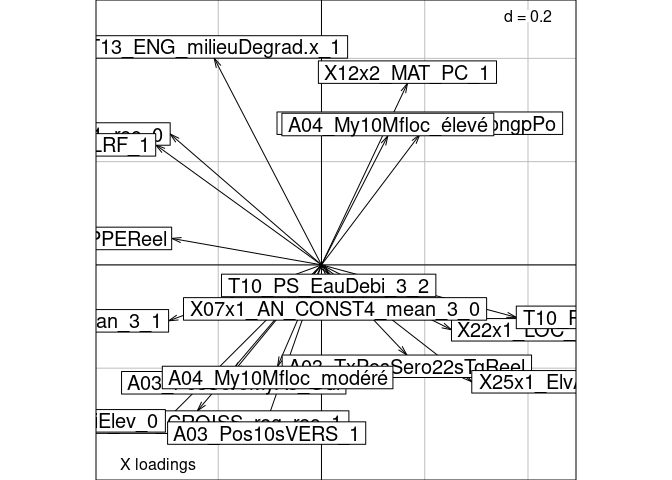

```r
res.plot[[5]]   # Variables Xk
```

Rôle faible : T10 ps eau debi 2, x07x1_an_const4_mean_3_0

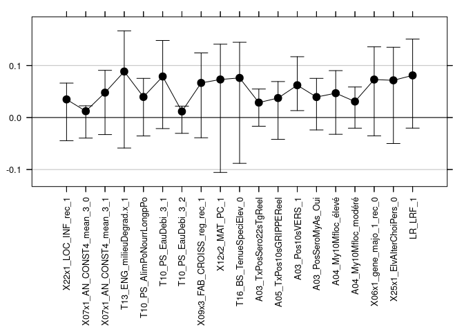

```r
plot(res.boot$vipc)                  # Importance des variables explicatives (pour tout le bloc Y ; seuil 1/P)
```

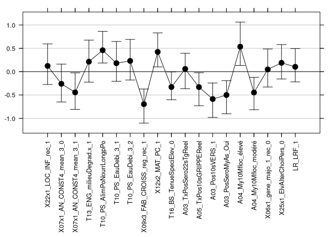

```r
plot(res.boot$XYcoef[[1]])           # Importance des variables explicatives (pour la variable y1 ; seuil 0)
```

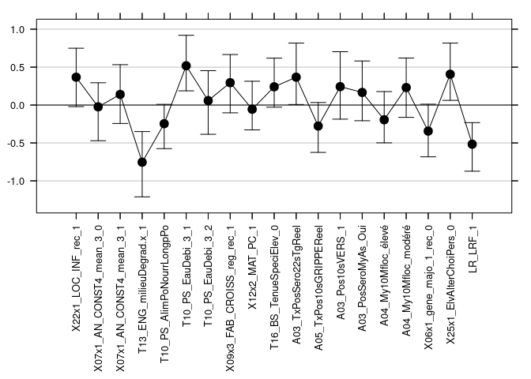

```r
plot(res.boot$XYcoef[[2]])           # Importance des variables explicatives (pour la variable y2 ; seuil 0)
```

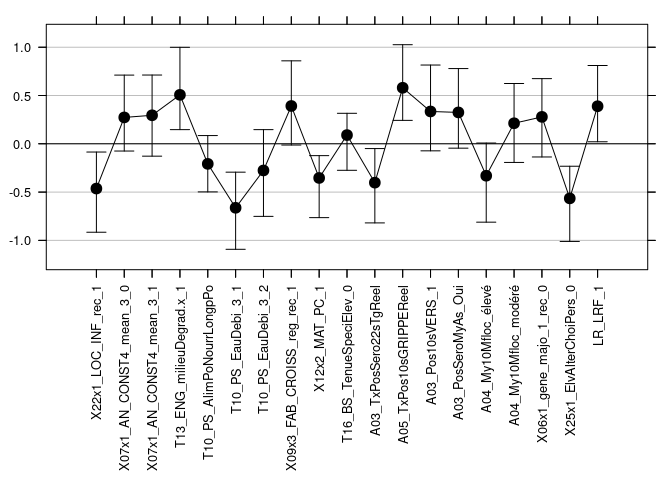

```r
plot(res.boot$XYcoef[[3]])           # Importance des variables explicatives (pour la variable y3 ; seuil 0)
```

### Suppr Variables Variables Non Significatives

```r
toujours_0 <- tjrs_0(res.boot)
names(toujours_0)[toujours_0]
```

```
## [1] "X07x1_AN_CONST4_mean_3_0" "T10_PS_EauDebi_3_2"
## [3] "X06x1_gene_majo_1_rec_0"
```

```r
toujours_0
```

```
##        X22x1_LOC_INF_rec_1   X07x1_AN_CONST4_mean_3_0
##                      FALSE                       TRUE
##   X07x1_AN_CONST4_mean_3_1   T13_ENG_milieuDegrad.x_1
##                      FALSE                      FALSE
##  T10_PS_AlimPoNourrLongpPo         T10_PS_EauDebi_3_1
##                      FALSE                      FALSE
##         T10_PS_EauDebi_3_2 X09x3_FAB_CROISS_reg_rec_1
##                       TRUE                      FALSE
##             X12x2_MAT_PC_1    T16_BS_TenueSpeciElev_0
##                      FALSE                      FALSE
##     A03_TxPosSero22sTgReel     A05_TxPos10sGRIPPEReel
##                      FALSE                      FALSE
##           A03_Pos10sVERS_1        A03_PosSeroMyAs_Oui
##                      FALSE                      FALSE
##        A04_My10Mfloc_élevé       A04_My10Mfloc_modéré
##                      FALSE                      FALSE
##    X06x1_gene_majo_1_rec_0   X25x1_ElvAlterChoiPers_0
##                       TRUE                      FALSE
##                   LR_LRF_1
##                      FALSE
```

On suprime alors X06x1_gene_majo_1_rec_0.

```r
var.suppr <- c("X06x1_gene_majo_1_rec")
var_dummy.suppr <- grep(paste(var.suppr, collapse = "|"), names(toujours_0), value = TRUE)
for(i in seq_along(data)) {
  data[[i]] <- data[[i]] %>%
    dplyr::select(-any_of(var_dummy.suppr))  # Explicit dplyr::select
}
# Détection si bloc vide et suppression
bloc.vide <- c()
for(i in 1:length(data)){
  if(ncol(data[[i]]) == 0){
    bloc.vide <- c(bloc.vide, i)
  }
}
bloc.vide # blocs a supprimer
```

```r
# data <- data[-bloc.vide]

# detection blocs a variables uniques
bloc.unic <- c()
for(i in 1:length(data)){
  if(ncol(data[[i]]) == 1){
    bloc.unic <- c(bloc.unic, i)
  }
}
bloc.unic
```

```r
names(data)
```

```
## [1] "X01_Logement_Entretien"         "X02_Alimentation"
## [3] "X04_Biosecurite"                "X05_Facteurs_Infectieux"
## [5] "X06_Caracteristiques_Generales" "Bloc_Y"
```

## Troisiéme mb-pls

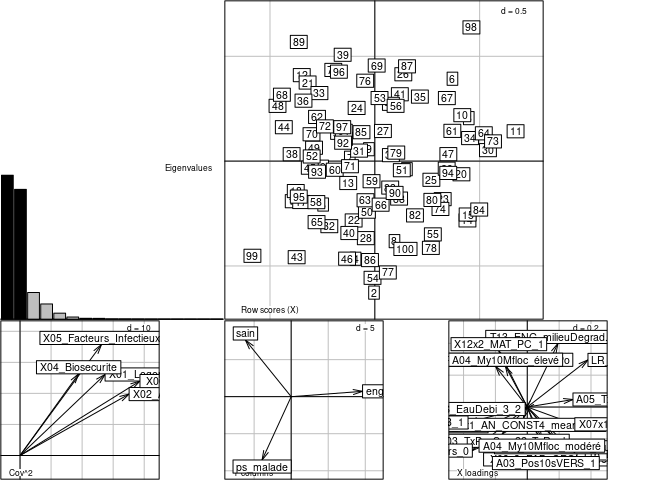

```r
dudiY.NE <- dudi.pca(Y, center = TRUE, scale = TRUE, scannf = FALSE)
ktabX.NE <- ktab.list.df(data[1:5])
res.mbpls2   <- mbpls(dudiY.NE, ktabX.NE, scale = TRUE, option = "uniform", scannf = F, nf = 10)
res.plot     <- plot(res.mbpls2)
```

```r
res.2foldcv2 <- testdim(res.mbpls2, nrepet = 500)  # calcul long
```

## Choix des dimensions

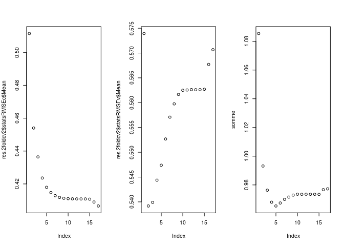

```r
par(mfrow = c(1, 3))
somme <- res.2foldcv2$statsRMSEv$Mean + res.2foldcv2$statsRMSEc$Mean
plot(res.2foldcv2$statsRMSEc$Mean)
plot(res.2foldcv2$statsRMSEv$Mean)
plot(somme)
```

```r
match(min(na.omit(somme)), somme)
```

```
## [1] 5
```

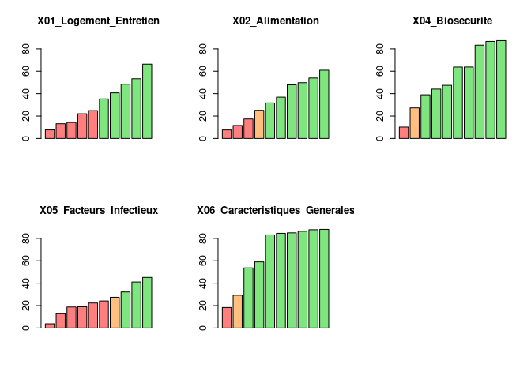

```r
par(mfrow = c(2, 3))
for(name in names(sum_res)[-1]){
    var.cum <- sum_res[[name]][,2]
    color <- ifelse(var.cum <= 25, red, ifelse(var.cum < 30, orange, green))
    barplot(var.cum,
            main=name,
            col = color,
            cex.main=1.25,
            cex.axis=1.2,
            ylim= c(0,87))
}

var.cum <- sum_res$YandX[,2]
color <- ifelse(var.cum <= 25, red, ifelse(var.cum < 30, orange, green))

par(mfrow = c(1, 2))
```

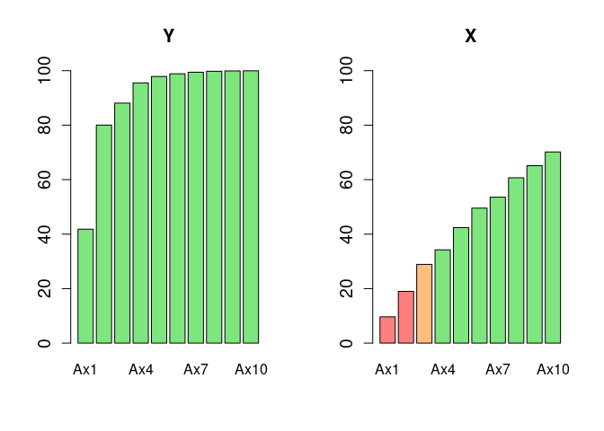

```r
barplot(var.cum,
            main="Y",
            col = color,
            cex.main=1.25,
            cex.axis=1.2,
            ylim= c(0,100))
var.cum <- sum_res$YandX[,4]
color <- ifelse(var.cum <= 25, red, ifelse(var.cum < 30, orange, green))

barplot(var.cum,
            main="X",
            col = color,
            cex.main=1.25,
            cex.axis=1.2,
            ylim= c(0,100))
```

## Analyse

```r
opt.dim <- 4
res.boot <- randboot(res.mbpls2, opt.dim, nrepet = 500) # calcul long
```

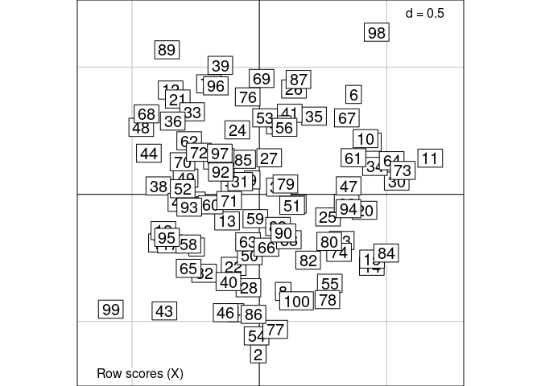

```r
res.plot[[1]]
```

## Blocs

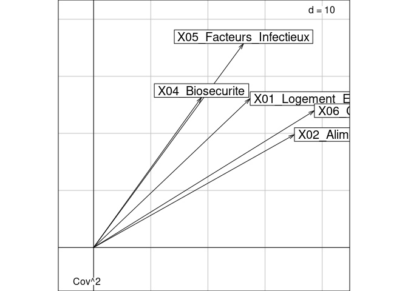

```r
res.plot[[3]]   # Blocs Xk
```

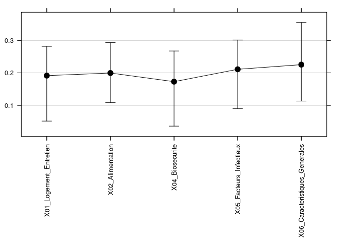

```r
plot(res.boot$bipc)                  # Importance des blocs explicatifs (seuil 1/K, K = nb blocs)
```

5 blocs X donc 1/k=20%; 0.2 Tous les blocs ont leur IC qui passe par 0.2 cependant, deux semblent être plus importants : Facteurs infectieux et caractéristiques géneŕales. Le moins : biosécurité.